# Tarea 2 - Representación de Soluciones

Arturo Itzcóatl Medina Ruiz

28/feb/2024

```python
import matplotlib.pyplot as plt
import pandas as pd
import numpy as np
import random
import time
plt.style.use('ggplot')
```

# Ejercicio 1. Representación binaria para números reales

## **a) Representación binaria de $\mathbb N^+$**

Definimos la representación binaria de un número natural por medio del siguiente mapeo. Dado un número $x\in A\subseteq\mathbb N^+$ y un número de bits $n\in \mathbb N^+$ se define $B:A\subseteq\mathbb N^+\rightarrow \{0,1\}^n$ como

$$B(x) = \left(
b_{n-1},b_{n-2},\cdots,b_0\right),\;\text{donde}\;
x=\displaystyle\sum_{i=0}^{n-1} b_i2^{i }$$

- Resulta sencillo probar, por inducción, que la representación binaria **siempre existe** para cualquier natural. El *hint* para el paso inductivo es notar que si $x$ es par se tiene que $x=2k = \sum_{i=1}^{n_k} b_i2^i$ y si $x$ es impar se tiene que $x=2k+1 = \sum_{i=0}^{n_k} b_i2^i$ con $b_0 = 1$.
- También es posible probar que la representación binaria propuesta es **única** ya que si $x = \sum_{i=0}^{n-1} b_i2^{i} = \sum_{i=0}^{n-1} c_i2^{i}$ entonces $0 = \sum_{i=0}^{n-1} (b_i - c_i)2^{i}$, lo que implica que $b_i=c_i\;\forall i$.

De las afirmaciones anteriores, y del hecho de que la cardinalidad del contradominio de $B$ es $2^n$, podemos cobncluir que $B$ es una biyección sobre los conjuntos $A=\{0,1,\cdots, 2^n-1\}$ y $\{0,1\}^n$. Por lo tanto, la cantidad de números representables con $n$ bits es de $2^n$, los números son $\{0,1,\cdots, 2^n-1\}$.

La implementación de la codificación en `python` consiste en descomponer en encontrar de forma iterativa el número máximo $k$ tal que $2^k < x$ y actualizar $x=x-2^k$ hasta extinguir $x$. De esta forma, cada $k$ encontrado representa a un valor binario $b_k$, la salida es una lista booleana con valor `True` en el índice $n-k-1$ para cada $k$ hallado y `False` en otro caso:

```python
def codificaN(x, n):
    """
    Codifica un número entero 'x' en una lista de bits de tamaño 'n'.

    Parameters:
    - x (int): El número entero a codificar.
    - n (int): El tamaño de la lista de bits.

    Returns:
    - list: Una lista de bits que representa la codificación de 'x'.

    Raises:
    - TypeError: Si 'x' o 'n' no son enteros.
    - ValueError: Si 'x' es negativo, 'n' es no positivo, o 'x' es mayor o igual a 2^'n'.
    """
    if not isinstance(x, int):
        raise TypeError("El argumento 'x' debe ser un entero.")
    if not isinstance(n, int):
        raise TypeError("El argumento 'n' debe ser un entero.")
    if x < 0:
        raise ValueError("El argumento 'x' debe ser un entero no negativo.")
    if n <= 0:
        raise ValueError("El argumento 'n' debe ser un entero positivo.")
    if n >= 2**n:
        raise ValueError(f"El argumento 'x' debe ser menor que {2**n}.")

    bits = [False] * n
    while x > 0:
        k = int(np.log2(x))
        bits[n - k - 1] = True
        x -= 2**k
    return bits
```

La decodificación de la representación binaria se realiza siguiendo la fórmula de la definición $\sum_{i=0}^{n-1} b_i2^{i }$, es decir, sumar a $x$ la potencia $2^k$ siempre que el valor de la lista booleana sea `True` en la casilla $n-k-1$:

```python
def decodificaN(bits):
    """
    Decodifica una lista de bits en un número entero.

    Parameters:
    - bits (list): Una lista de bits representados como booleanos.

    Returns:
    - int: El número entero decodificado.

    Raises:
    - TypeError: Si 'bits' no es una lista o si alguno de sus elementos no es booleano.
    - ValueError: Si 'bits' está vacía.
    """
    if not isinstance(bits, list):
        raise TypeError("El argumento 'bits' debe ser una lista.")
    if not all(isinstance(bit, bool) for bit in bits):
        raise TypeError("Los elementos de 'bits' deben ser booleanos.")
    if len(bits) <= 0:
        raise ValueError("La lista 'bits' no puede estar vacía.")
    x = 0
    n = len(bits)
    for i, bit in enumerate(bits):
        if bit:
            x += 2 ** (n - 1 - i)
    return x
```

También se creó la siguiente función para poder tener una representación visual de la codificación:

```python
def bits_to_str(bits):
    if isinstance(bits[0], list):
        return [''.join([str(int(x)) for x in bits]) for bits in bits]
    return ''.join([str(int(x)) for x in bits])
```

Ejemplos de uso:

*Codificación:*

```python
# Codificación de 4 en 4 bits:
print(4, '=', bits_to_str(codificaN(4, 4)))
```

```
## 4 = 0100
```

```python
# Codificación de 16626 en 8 bits:
print(16626, '=', bits_to_str(codificaN(16626, 8)))
```

```
## 16626 = 11110010
```

```python
# Codificación de 15165901 en 16 bits:
print(15165901, '=',bits_to_str(codificaN(15165901, 16)))
```

```
## 15165901 = 0110100111101111
```

*Decodificación:*

```python
# Decodificación de [True, True, True, False, True]
x = [True, True, True, False, True]
print(bits_to_str(x), '=', decodificaN(x))
```

```
## 11101 = 29
```

```python
# Decodificación de [True, False, True, True, False, False, True, True]
x = [True, False, True, True, False, False, True, True]
print(bits_to_str(x), '=', decodificaN(x))
```

```
## 10110011 = 179
```

```python
# Decodificación de [False, False, True, True, False, True, True, False, True,
#                   True, False, False, True, False, True, True]
x = [False, False, True, True, False, True, True, False, True,
    True, False, False, True, False, True, True]
print(bits_to_str(x), '=', decodificaN(x))
```

```
## 0011011011001011 = 14027
```

## **b) Representación binaria en $\mathbb R$**

Para conseguir una representación binaria uniforme de un intervalo real $[a,b]$ podemos utilizar el ejecicio anterior definiendo una transformación lineal $f$ del intervalo $[a,b]$ sobre el conjunto $\{0,1,\cdots, 2^n-1\}$, es decir $f:[a,b]\rightarrow\{0,1,\cdots, 2^n-1\}$, tal que
$$f(x) = \left\lfloor \frac{(2 ^ n -
1) (x - a)}{b - a}\right\rfloor$$

Donde $\lfloor\rfloor$ es la función *floor* o *máximo entero*. De esta forma, la representación binaria para $x\in[a,b]$, con $n$, dígitos está data por $(b_{n-1},b_{n-2},\cdots,b_0)$ tal que $f(x) = \sum_{i=0}^{n-1} b_i2^{i}$. En el siguiente gráfico se representa la codificación binaria del intevalo $[0,1]$ utilizando 4 dígitos:

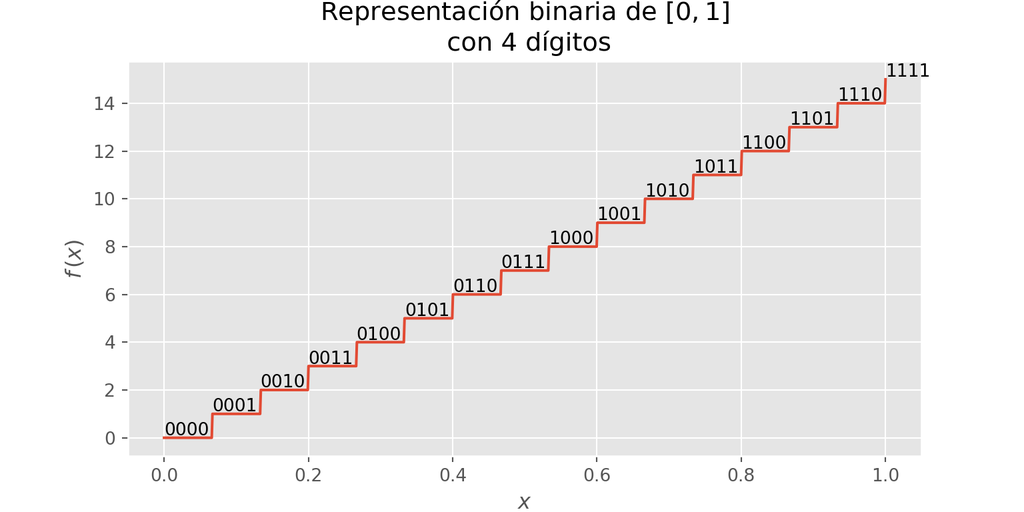

El proceso de decodificación se lleva a cabo en dos partes, primero transformamos de bits a enteros con la misma función que definimos en el ejercicio anterior, posteriormente aplicamos una transformación lineal $f^{-1}$ del intervalo $\{0,1,\cdots, 2^n-1\}$ sobre $[a, b]$, la cual está data por:
$$f^{-1}(x) = a + (b-a)
\frac{x}{2^n-1}$$

Para calcular la precisión máxima de la representación tenemos que encontrar la distancia mínima que existe entre los valores de la imagen de la función $f^{-1}$, es decir $d_{\text{min}}=min\{\left.|x-y|\right| x,y \in \text{Im}(f^{-1})\}$, además, como la función $f^{-1}$ es creciente basta con calcular la distancia mínima $f^{-1}$ que hay entre dos valores consecutivos de $\{0,1,\cdots, 2^n-1\}$:

$$\begin{aligned}
\left|f^{-1}(k)-f^{-1}(k-1)\right|
&= \left|a + (b-a) \frac{k}{2^n-1} -\left(a + (b-a)
\frac{k-1}{2^n-1}\right) \right|\\
&= \left|a + (b-a) \frac{k}{2^n-1} -a + -(b-a) \frac{k-1}{2^n-1}
\right|\\
&= \left| (b-a) \left(\frac{k}{2^n-1} -\frac{k-1}{2^n-1}
\right)\right|\\
&= \left| (b-a) \left(\frac{k-(k-1)}{2^n-1}\right)\right|\\
&= \frac{b-a}{2^n-1}
\end{aligned}$$
Así, la distancia mínima de la codificación es $d_{\text{min}} = \frac{b-a}{2^n-1}$, por lo que la máxima precisión en dígitos es:
$$-\log_{10}
\left(\frac{b-a}{2^n-1}\right)$$

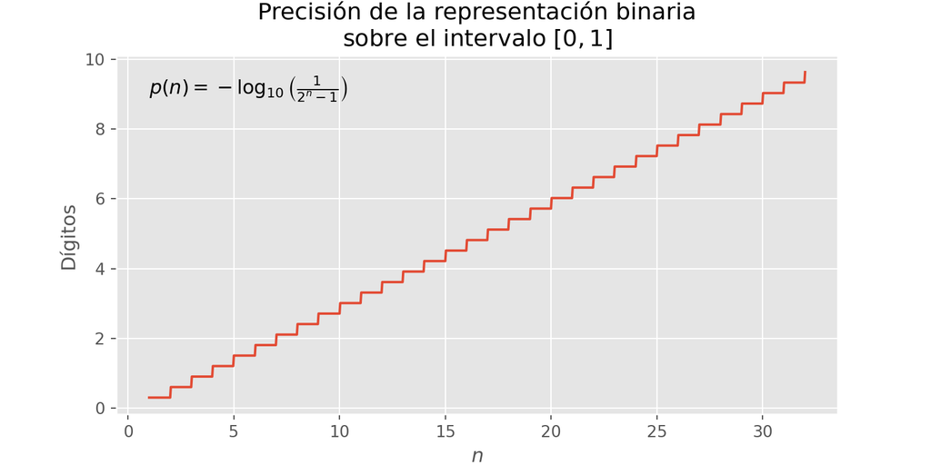

## **c) Codificación en $\mathbb R$**

Haciendo uso de la función para codificar enteros, implementada en el inciso `a)`, y de función $f$, descrita en el inciso `b)`, se implementa la función para realizar la codificación binaria de números reales en un intervalo $[a,b]$:

```python
def codificaR(x, n, a, b):
    """
    Codifica un número real 'x' en una lista de bits de tamaño 'n'.

    Parameters:
    - x (int, float): El número real a codificar.
    - n (int): El tamaño de la lista de bits.
    - a (int, float): El límite inferior del rango de codificación.
    - b (int, float): El límite superior del rango de codificación.

    Returns:
    - list: Una lista de bits que representa la codificación de 'x'.

    Raises:
    - TypeError: Si 'x' no es un número, 'n' no es un entero, 'a' no es un número, o 'b' no es un número.
    - ValueError: Si 'a' es mayor o igual que 'b', 'x' está fuera del rango [a, b], o 'n' no es un entero positivo.
    """
    if not isinstance(x, (int, float)):
        raise TypeError("El argumento 'x' debe ser un número.")
    if not isinstance(n, int):
        raise TypeError("El argumento 'n' debe ser un entero.")
    if not isinstance(a, (int, float)):
        raise TypeError("El argumento 'a' debe ser un número.")
    if not isinstance(b, (int, float)):
        raise TypeError("El argumento 'b' debe ser un número.")
    if a >= b:
        raise ValueError("El argumento 'a' debe ser menor que 'b'.")
    if x < a or x > b:
        raise ValueError("El argumento 'x' debe estar en el rango [a, b].")
    if n <= 0:
        raise ValueError("El argumento 'n' debe ser un entero positivo.")
    return codificaN(int((2 ** n - 1) * (x - a) / (b - a)), n)
```

Ejemplos de uso:

```python
# Codificación de 0.75 en el rango [0, 1] con 8 bits:
bits_to_str(codificaR(0.75, 8, 0, 1))
```

```
## '10111111'
```

```python
# Codificación de -3 en el rango [-10, 10] con 16 bits:
bits_to_str(codificaR(-3, 16, -10, 10))
```

```
## '0101100110011001'
```

```python
# Codificación de 175 en el rango [100, 200] con 10 bits:
bits_to_str(codificaR(175, 10, 100, 200))
```

```
## '1011111111'
```

## **d) Decodificación en $\mathbb R$**

Por medo de la función para decodificar enteros, implementada en el inciso `a)`, y de función $f^{-1}$, descrita en el inciso `b)`, se implementa la función para realizar la decodificación de valores binarios a reales en un intervalo $[a,b]$:

```python
def decodificaR(bits, a, b):
    """
    Decodifica una lista de bits en un número real.

    Parameters:
    - bits (list): Una lista de bits representados como booleanos.
    - a (int, float): El límite inferior del rango de decodificación.
    - b (int, float): El límite superior del rango de decodificación.

    Returns:
    - int, float: El número real decodificado.

    Raises:
    - TypeError: Si 'bits' no es una lista, si alguno de sus elementos no es booleano, 'a' no es un número, o 'b' no es un número.
    - ValueError: Si 'bits' está vacía o si 'a' es mayor o igual que 'b'.
    """
    if not isinstance(bits, list):
        raise TypeError("El argumento 'bits' debe ser una lista.")
    if not all(isinstance(bit, bool) for bit in bits):
        raise TypeError("Los elementos de 'bits' deben ser booleanos.")
    if len(bits) <= 0:
        raise ValueError("La lista 'bits' no puede estar vacía.")
    if not isinstance(a, (int, float)):
        raise TypeError("El argumento 'a' debe ser un número.")
    if not isinstance(b, (int, float)):
        raise TypeError("El argumento 'b' debe ser un número.")
    if a >= b:
        raise ValueError("El argumento 'a' debe ser menor que 'b'.")
    return a + (b-a) * decodificaN(bits) / (2 ** len(bits) - 1)
```

Ejemplos de uso:

```python
# Decodificación de [True, False, True, False, True, False, True, False] en el rango [0, 1]:
decodificaR([True, False, True, False, True, False, True, False], 0, 1)
```

```
## 0.6666666666666666
```

```python
# Decodificación de [True, True, True, True, False, False, True, True, False,
#                   True, False, False, True, False, True, True] en el rango [-10, 10]
decodificaR([True, True, True, True, False, False, True, True, False,
            True, False, False, True, False, True, True], -10, 10)
```

```
## 9.007553215838865
```

```python
# Decodificación de [True, False, True, False, True, False, True,
#                   True, False, True, False, False] en el rango [100, 200]:
decodificaR([True, False, True, False, True, False, True,
            True, False, True, False, False], 100, 200)
```

```
## 166.9108669108669
```